# Brand prediction

16 de marzo de 2019

## Defining the problem

The sales team engaged a market research firm to conduct a survey of our existing customers.

- Objective: *find out which of two brands of computers our customers prefer*.
- Problem: the answer to the brand preference question was not properly captured for all of the respondents.

Our work in that task would be:

1. to investigate if customer responses to some survey questions (e.g. income, age, etc.) enable us to predict the answer to the brand preference question.
2. to make those predictions and provide the sales team with a complete view of what brand our customers prefer.

## Import the data

```r
library(dplyr)
glimpse(completed_survey)
```

```
## Observations: 9,898
## Variables: 7
## $ salary  <dbl> 119806.54, 106880.48, 78020.75, 63689.94, 50873.62, 13...
## $ age     <int> 45, 63, 23, 51, 20, 56, 24, 62, 29, 41, 48, 52, 52, 33...
## $ elevel  <int> 0, 1, 0, 3, 3, 3, 4, 3, 4, 1, 4, 1, 3, 4, 2, 1, 2, 1, ...
## $ car     <int> 14, 11, 15, 6, 14, 14, 8, 3, 17, 5, 16, 6, 20, 13, 6, ...
## $ zipcode <int> 4, 6, 2, 5, 4, 3, 5, 0, 0, 4, 5, 0, 4, 3, 3, 4, 7, 2, ...
## $ credit  <dbl> 442037.71, 45007.18, 48795.32, 40888.88, 352951.50, 13...
## $ brand   <int> 0, 1, 0, 1, 0, 1, 1, 1, 0, 1, 1, 0, 1, 0, 0, 1, 1, 0, ...
```

```r
glimpse(incompleted_survey)
```

```
## Observations: 5,000
## Variables: 7
## $ salary  <dbl> 110499.74, 140893.78, 119159.65, 20000.00, 93956.32, 4...
## $ age     <int> 54, 44, 49, 56, 59, 71, 32, 33, 32, 58, 22, 47, 41, 40...
## $ elevel  <int> 3, 4, 2, 0, 1, 2, 1, 4, 1, 2, 1, 4, 2, 4, 3, 1, 4, 3, ...
## $ car     <int> 15, 20, 1, 9, 15, 7, 17, 17, 19, 8, 12, 12, 1, 9, 4, 1...
## $ zipcode <int> 4, 7, 3, 1, 1, 2, 1, 0, 2, 4, 1, 2, 3, 2, 4, 3, 8, 8, ...
## $ credit  <dbl> 354724.18, 395015.34, 122025.09, 99629.62, 458679.83, ...
## $ brand   <int> 0, 0, 0, 0, 0, 0, 0, 0, 0, 0, 0, 0, 0, 0, 0, 0, 0, 0, ...
```

## Data wrangling: giving names

Let's put the brand information in a nicer way:

```r
# transform the survey result to names
completed_survey$brand_name <- apply(completed_survey["brand"],
                                     MARGIN = 2,
                                     function(x) if_else(x == 0, "Acer", "Sony"))
```

| salary | age | elevel | car | zipcode | credit | brand | brand_name |
| --- | --- | --- | --- | --- | --- | --- | --- |
| 119806.54 | 45 | 0 | 14 | 4 | 442037.71 | 0 | Acer |
| 106880.48 | 63 | 1 | 11 | 6 | 45007.18 | 1 | Sony |
| 78020.75 | 23 | 0 | 15 | 2 | 48795.32 | 0 | Acer |
| 63689.94 | 51 | 3 | 6 | 5 | 40888.88 | 1 | Sony |
| 50873.62 | 20 | 3 | 14 | 4 | 352951.50 | 0 | Acer |
| 130812.74 | 56 | 3 | 14 | 3 | 135943.02 | 1 | Sony |

## Data wrangling: tranforming to factor

```r
categ_var <- c("elevel", "car", "zipcode", "brand_name")
completed_survey[categ_var] <- lapply(completed_survey[categ_var], as.factor)

# let's check the structure of the dataset
glimpse(completed_survey)
```

```
## Observations: 9,898
## Variables: 8
## $ salary     <dbl> 119806.54, 106880.48, 78020.75, 63689.94, 50873.62,...
## $ age        <int> 45, 63, 23, 51, 20, 56, 24, 62, 29, 41, 48, 52, 52,...
## $ elevel     <fct> 0, 1, 0, 3, 3, 3, 4, 3, 4, 1, 4, 1, 3, 4, 2, 1, 2, ...
## $ car        <fct> 14, 11, 15, 6, 14, 14, 8, 3, 17, 5, 16, 6, 20, 13, ...
## $ zipcode    <fct> 4, 6, 2, 5, 4, 3, 5, 0, 0, 4, 5, 0, 4, 3, 3, 4, 7, ...
## $ credit     <dbl> 442037.71, 45007.18, 48795.32, 40888.88, 352951.50,...
## $ brand      <int> 0, 1, 0, 1, 0, 1, 1, 1, 0, 1, 1, 0, 1, 0, 0, 1, 1, ...
## $ brand_name <fct> Acer, Sony, Acer, Sony, Acer, Sony, Sony, Sony, Ace...
```

```r
# We can apply the same process to the incomplete survey
incompleted_survey$brand_name <- apply(incompleted_survey["brand"],
                                       MARGIN = 2,
                                       function(x) if_else(x == 0, "Acer", "Sony"))
incompleted_survey[categ_var] <- lapply(incompleted_survey[categ_var], as.factor)
```

## 1st exploration

Understand the brand preference with the **complete survey**.

- Table of absolute frequency

```r
table(completed_survey$brand_name, dnn = c("Brand"))
```

```
## Brand
## Acer Sony
## 3744 6154
```

- Table of relative frequency

```r
round(prop.table(table(completed_survey$brand_name, dnn = c("Brand"))),2)
```

```
## Brand
## Acer Sony
## 0.38 0.62
```

## 1st modalisation

```r
library(caret)
set.seed(2019)

# train and test
train_ids <- createDataPartition(y = completed_survey$brand,
                                 p = 0.75,
                                 list = F)
train <- completed_survey[train_ids,]
test <- completed_survey[-train_ids,]

# cross validation
ctrl <- trainControl(method = "repeatedcv",
                     repeats = 5,
                     number = 3)

# Creating the model with caret and using the model rpart
mod_caret_dt <- caret::train(brand_name ~ .,
                             data = train %>% dplyr::select(-brand),
                             method = "rpart",
                             trControl = ctrl)
```

## 1st error check: Accuracy and kappa

### Results on train

```r
train_results <- predict(object = mod_caret_dt,
                         newdata = train)
postResample(train$brand_name, train_results)
```

```
##  Accuracy     Kappa
## 0.8634159 0.7056679
```

### Results on test

```r
test_results <- predict(object = mod_caret_dt,
                        newdata = test)
postResample(test$brand_name, test_results)
```

```
##  Accuracy     Kappa
## 0.8666128 0.7095651
```

## 1st error check: variable importance

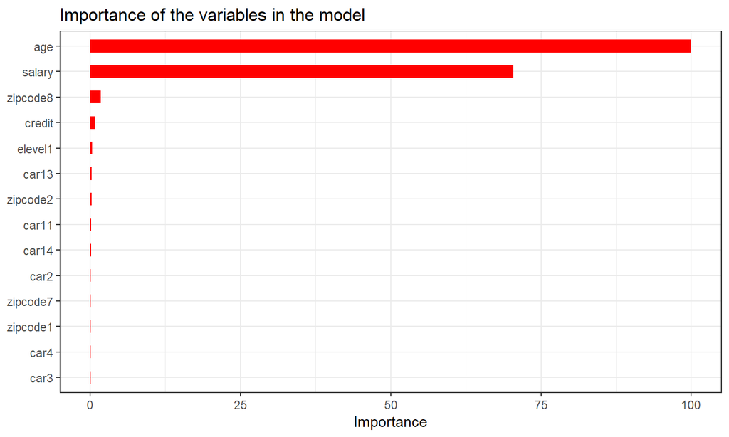

## 1st error check: confusion matrix

### Confusion matrix on train

```r
round(prop.table(confusionMatrix(train$brand_name, train_results)$table),2)
```

```
##           Reference
## Prediction Acer Sony
##       Acer 0.30 0.08
##       Sony 0.05 0.57
```

### Confusion matrix on test

```r
round(prop.table(confusionMatrix(test$brand_name, test_results)$table),2)
```

```
##           Reference
## Prediction Acer Sony
##       Acer 0.29 0.08
##       Sony 0.05 0.58
```

## 2nd exploration

Looking for the relation between the important variable and brand. **Goal** create a model that is not overfitted to the data:

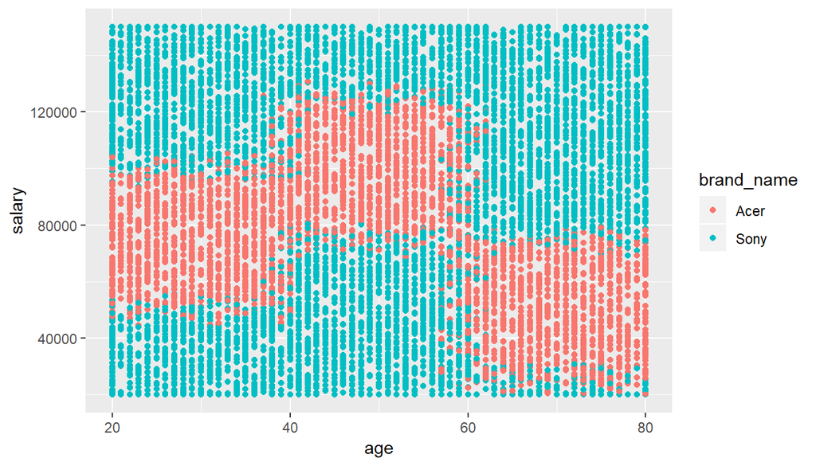

```r
completed_survey %>%
  ggplot(aes(age, salary)) +
    geom_point(aes(color = brand_name))
```

### Results on train

```r
train_results_2ndmod <- predict(object = mod_caret_dt_subs,
                                newdata = train)
postResample(train$brand_name, train_results_2ndmod)
```

```
##  Accuracy     Kappa
## 0.8634159 0.7056679
```

### Results on test

```r
test_results_2ndmod <- predict(object = mod_caret_dt_subs,
                               newdata = test)
postResample(test$brand_name, test_results_2ndmod)
```

```
##  Accuracy     Kappa
## 0.8666128 0.7095651
```

## 2nd error check: confusion matrix

We are going to compare the confusion matrix for the first model (all the variables) and the model with salary and age:

### Rpart model with all the variables

```r
round(prop.table(confusionMatrix(test$brand_name, test_results)$table),2)
```

```
##           Reference
## Prediction Acer Sony
##       Acer 0.29 0.08
##       Sony 0.05 0.58
```

### Rpart model with only salary and age

```r
round(prop.table(confusionMatrix(test$brand_name, test_results_2ndmod)$table),2)
```

```
##           Reference
## Prediction Acer Sony
##       Acer 0.29 0.08
##       Sony 0.05 0.58
```

## 2nd error check: visualization of the errors

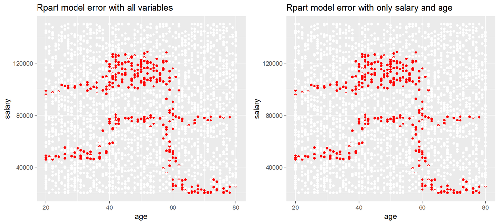

## 3rd modalization

Creation of the model with **KNN**

```r
# Creating the model with caret and using the model rpart
mod_caret_knn_subs <- caret::train(brand_name ~ salary + age,
                                   data = train %>% dplyr::select(-brand),
                                   method = "knn",
                                   trControl = ctrl,
                                   preProcess = c("center","scale"))
```

## 3rd error check: train and test metrics

### Results on train

```r
train_results_3rdmod <- predict(object = mod_caret_knn_subs,
                                newdata = train)
postResample(train$brand_name, train_results_3rdmod)
```

```
##  Accuracy     Kappa
## 0.9335938 0.8597098
```

### Results on test

```r
test_results_3rdmod <- predict(object = mod_caret_knn_subs,
                                 newdata = test)
postResample(test$brand_name, test_results_3rdmod)
```

```
##  Accuracy     Kappa
## 0.9223929 0.8340976
```

## 3rd error check: confusion matrix

### rpart model with only salary and age

```r
round(prop.table(confusionMatrix(test$brand_name, test_results_2ndmod)$table),2)
```

```
##           Reference
## Prediction Acer Sony
##       Acer 0.29 0.08
##       Sony 0.05 0.58
```

### knn model with only salary and age

```r
round(prop.table(confusionMatrix(test$brand_name, test_results_3rdmod)$table),2)
```

```
##           Reference
## Prediction Acer Sony
##       Acer 0.33 0.04
##       Sony 0.04 0.59
```

## 3rd error check: visualization of the errors

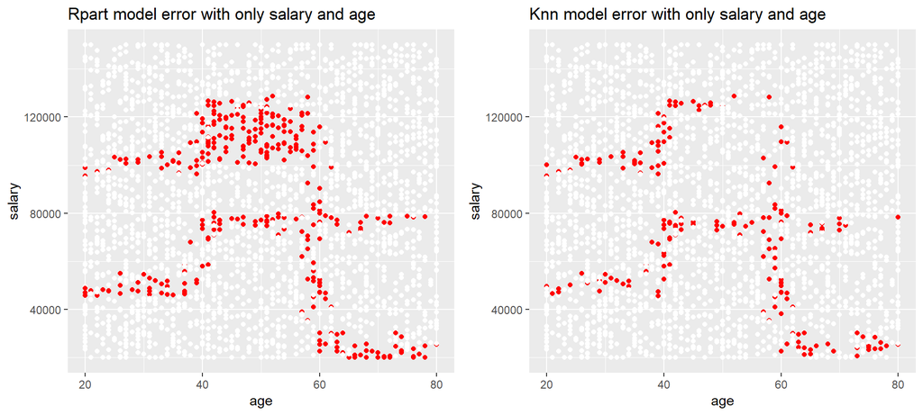

## 4rth modalisation: trying SVM algorithm

```r
library(e1071)
mod_svm <- svm(brand_name ~ salary + age,
               data = train)
```

### Results on train

```r
train_results_4rthmod <- predict(object = mod_svm,
                                newdata = train)
postResample(train$brand_name, train_results_4rthmod)
```

```
##  Accuracy     Kappa
## 0.9172953 0.8253844
```

### Results on test

```r
test_results_4rthmod <- predict(object = mod_svm,
                                newdata = test)
postResample(test$brand_name, test_results_4rthmod)
```

```
##  Accuracy     Kappa
## 0.9215845 0.8325183
```

## 4rth error check: confusion matrix

### KNN model with only salary and age

```r
# rpart model with only salary and age
round(prop.table(confusionMatrix(test$brand_name, test_results_3rdmod)$table),3)
```

```
##           Reference
## Prediction  Acer  Sony
##       Acer 0.334 0.037
##       Sony 0.040 0.588
```

### SVM model with only salary and age

```r
# rpart model with only salary and age
round(prop.table(confusionMatrix(test$brand_name, test_results_4rthmod)$table),3)
```

```
##           Reference
## Prediction  Acer  Sony
##       Acer 0.335 0.037
##       Sony 0.042 0.587
```

## 4rth error check: error visualization

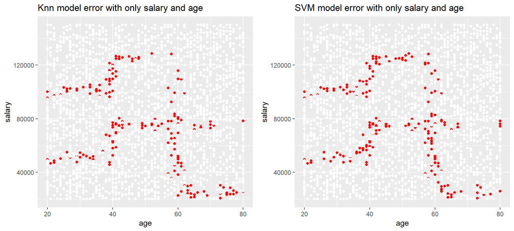

## Extra: support lines plot for SVM

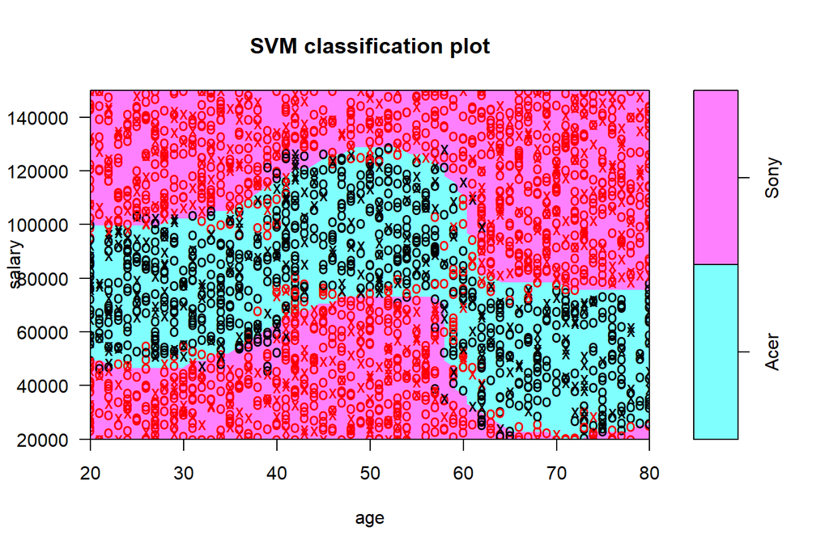